# Assignment 1: Python & Image Processing Fundamentals

### Student Information

Name: ---------Marah Ahmad Aljabali---------------  
Student ID: -------------220210525-----------  
Date: ----------14 Dec 2025---------------------- Updated at: ----------19 Dec 2025----------------------

### Import Required Libraries

Run this cell first to import all necessary libraries.

```python
import numpy as np
import matplotlib.pyplot as plt
from matplotlib import image
import matplotlib.patches as patches

# For consistent random results
np.random.seed(42)
```

# Part A: NumPy Fundamentals

### Q1: NumPy Array Operations

Create a NumPy array containing the first 20 even numbers (starting from 2). Then:

1. Square each element
2. Select only elements greater than 100
3. Calculate the mean of the resulting array

```python
# Step 1: Create array of first 20 even numbers
even_numbers = np.arange(2, 42, 2)
print("Even Numbers:", even_numbers)
print(f"Length of the even numbers array: {len(even_numbers)}")
# Step 2: Square each element
squared_numbers = even_numbers**2
print("Squared Numbers:", squared_numbers)

# Step 3: Select elements > 100
greater_than_100 = squared_numbers[squared_numbers > 100]
print("Elements greater than 100:", greater_than_100)
# Step 4: Calculate mean
mean = np.mean(greater_than_100)
print("Mean of elements greater than 100:", mean)
```

```
Even Numbers: [ 2  4  6  8 10 12 14 16 18 20 22 24 26 28 30 32 34 36 38 40]
Length of the even numbers array: 20
Squared Numbers: [   4   16   36   64  100  144  196  256  324  400  484  576  676  784
  900 1024 1156 1296 1444 1600]
Elements greater than 100: [ 144  196  256  324  400  484  576  676  784  900 1024 1156 1296 1444
 1600]
Mean of elements greater than 100: 750.6666666666666
```

### Q2: Matrix Manipulation

Create a 4×4 matrix where:

- The diagonal elements are 5
- All other elements are 1

Then, extract the 2×2 sub-matrix from the top-right corner.

```python
# Step 1: Create 4x4 matrix with ones
matrix = np.ones((4, 4), dtype=int)
print("Initial 4x4 Matrix:\n", matrix)
# Step 2: Set diagonal elements to 5
np.fill_diagonal(matrix, 5)
print("Matrix after setting diagonal elements to 5:\n", matrix)
# Step 3: Extract top-right 2x2 sub-matrix
top_right_submatrix = matrix[:2, 2:]
print("Top-right 2x2 sub-matrix:\n", top_right_submatrix)
```

```
Initial 4x4 Matrix:
 [[1 1 1 1]
 [1 1 1 1]
 [1 1 1 1]
 [1 1 1 1]]
Matrix after setting diagonal elements to 5:
 [[5 1 1 1]
 [1 5 1 1]
 [1 1 5 1]
 [1 1 1 5]]
Top-right 2x2 sub-matrix:
 [[1 1]
 [1 1]]
```

### Q3: Boolean Indexing

Given the array: `arr = np.array([12, 45, 23, 67, 34, 89, 56, 21])`

1. Create a new array containing only elements between 30 and 70 (inclusive)
2. Replace all elements greater than 50 with the value 50

```python
# Given array
arr = np.array([12, 45, 23, 67, 34, 89, 56, 21])

# Step 1: Select elements between 30 and 70 (inclusive)
selected_elements = np.array([], dtype=int)
for element in arr:
  if 30 <= element <= 70:
    selected_elements = np.append(selected_elements, element)
print("Selected elements between 30 and 70:", str(selected_elements))

# Step 2: Replace elements > 50 with 50
for i in range(len(arr)):
  if arr[i] > 50:
    arr[i] = 50
print("Array after replacing elements > 50 with 50:", arr)
```

```
Selected elements between 30 and 70: [45 67 34 56]
Array after replacing elements > 50 with 50: [12 45 23 50 34 50 50 21]
```

# Part B: Image Processing

First, let's load the penguin image.

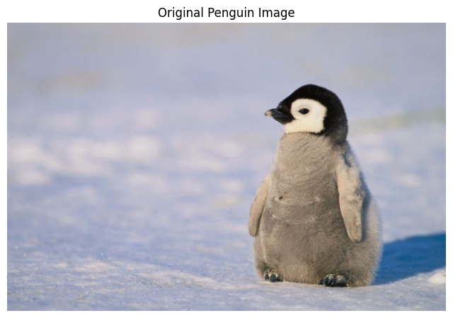

```python
# Load the penguin image
penguin = image.imread("penguin.jpg")

# Display the original image
plt.figure(figsize=(8, 6))
plt.imshow(penguin)
plt.title("Original Penguin Image")
plt.axis('off')
plt.show()
```

### Q4: Basic Image Operations

Load the image `penguin.jpg` and answer:

1. What are the dimensions of the image?
2. What is the data type of the pixel values?
3. What is the RGB value of the pixel at position (100, 200)?

```python
# Step 1: Get image dimensions
shape = penguin.shape
print("Image dimensions:", shape)
# Step 2: Get data type
print("Data type:", penguin.dtype)
# Step 3: Get RGB value at position (100, 200)
# Note: Remember the order is (row, column) not (x, y)
rgb_value = penguin[100, 200]  # == pixel at (row 100, column 200)
print("RGB value at position (100, 200):", rgb_value)
```

```
Image dimensions: (440, 670, 3)
Data type: uint8
RGB value at position (100, 200): [179 181 202]
```

### Q5: Image Cropping

Crop the penguin's face region defined by coordinates:

- Top-left: (300, 50)
- Bottom-right: (550, 250)

Display both the original and cropped images side by side using `plt.subplot()`.

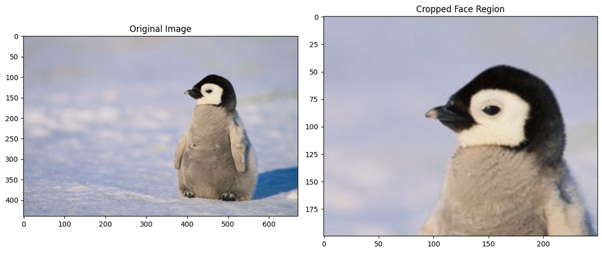

```python
# Step 1: Crop the face region
# Remember: penguin[rows, columns]
face_region = penguin[50:250, 300:550]

# Step 2: Display both images side by side
plt.figure(figsize=(12, 5))

# Original image
plt.subplot(1, 2, 1)
plt.imshow(penguin)
plt.title("Original Image")

# Cropped image
plt.subplot(1, 2, 2)
plt.imshow(face_region)
plt.title("Cropped Face Region")

plt.tight_layout()
plt.show()
```

### Q6: Color Manipulation

Create three separate images showing only:

1. The red channel
2. The green channel
3. The blue channel

Display them in a single figure with 1 row and 3 columns.

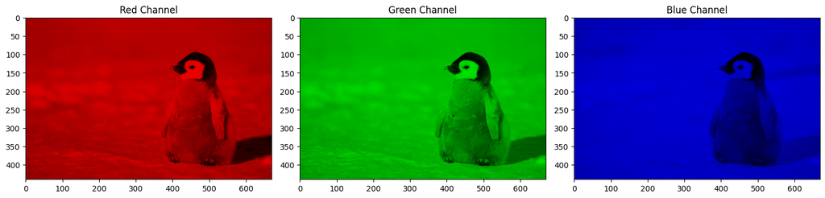

```python
# Step 1: Create red channel image
red_channel = np.zeros_like(penguin)
red_channel[:, :, 0] = penguin[:, :, 0]

# Step 2: Create green channel image
green_channel = np.zeros_like(penguin)
green_channel[:, :, 1] = penguin[:, :, 1]

# Step 3: Create blue channel image
blue_channel = np.zeros_like(penguin)
blue_channel[:, :, 2] = penguin[:, :, 2]

# Step 4: Display all three channels
plt.figure(figsize=(15, 5))

# Red channel
plt.subplot(1, 3, 1)
plt.imshow(red_channel)
plt.title("Red Channel")

# Green channel
plt.subplot(1, 3, 2)
plt.imshow(green_channel)
plt.title("Green Channel")
# Blue channel
plt.subplot(1, 3, 3)
plt.imshow(blue_channel)
plt.title("Blue Channel")

plt.tight_layout()
plt.show()
```

### Q7: Image Anonymization

Make the penguin anonymous by:

1. Covering the eye with black rectangles
2. Covering the beak with a white rectangle
3. Display the modified image

Eye coordinates: (440, 125)→(470, 145) Beak coordinates: (390, 125)→(420, 145)

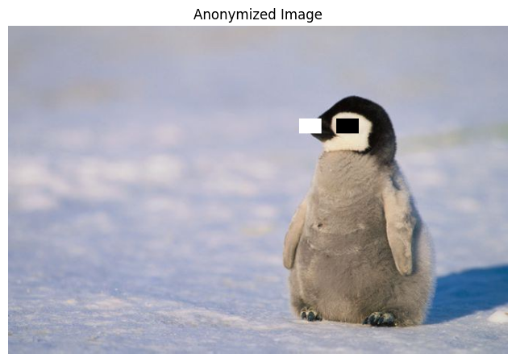

```python
# Step 1: Create a copy of the image
im_copy = np.copy(penguin)
# Step 2: Cover the eye with black rectangle
left = im_copy[125:145 , 440:470] = [0, 0, 0]

# Step 3: Cover beak with white rectangle
beak = im_copy[125:145 , 390:420] = [255, 255, 255]

# Step 4: Display the anonymized image
plt.figure(figsize=(8, 6))
plt.imshow(im_copy)
plt.title("Anonymized Image")
plt.axis('off')
plt.show()
```

# Part C: Advanced Operations

### Q8: Grayscale Conversion

Convert the penguin image to grayscale using three different methods:

1. Simple average method: `(R + G + B) / 3`
2. Weighted method: `0.299R + 0.587G + 0.114B`
3. Lightness method: `(max(R,G,B) + min(R,G,B)) / 2`

Display all three results and compare them.

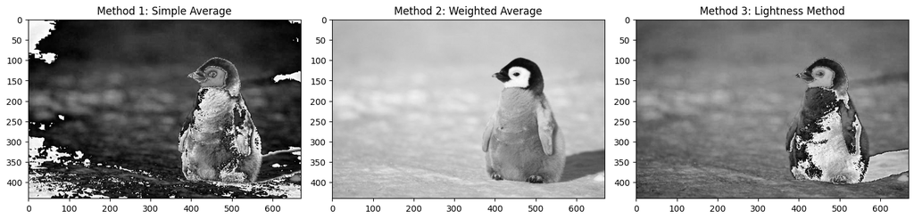

```python
# Method 1: Simple average
gray_simple = (penguin[:, :, 0] + penguin[:, :, 1] + penguin[:, :, 2]) / 3

# Method 2: Weighted average (luminosity method)
gray_weighted = 0.299 * penguin[:, :, 0] + 0.587 * penguin[:, :, 1] + 0.114 * penguin[:, :, 2]

# Method 3: Lightness method
gray_lightness = (np.max(penguin, axis=2) + np.min(penguin, axis=2)) / 2
# Display all three methods
plt.figure(figsize=(15, 5))

# Method 1
plt.subplot(1, 3, 1)
plt.imshow(gray_simple, cmap='gray')
plt.title("Method 1: Simple Average")

# Method 2
plt.subplot(1, 3, 2)
plt.imshow(gray_weighted, cmap='gray')
plt.title("Method 2: Weighted Average")

# Method 3
plt.subplot(1, 3, 3)
plt.imshow(gray_lightness, cmap='gray')
plt.title("Method 3: Lightness Method")

plt.tight_layout()
plt.show()
```

### Q9: Image Transformation

Create a new image by:

1. Taking the left half of the original penguin image
2. Flipping it horizontally
3. Stacking it with the right half to create a symmetric image

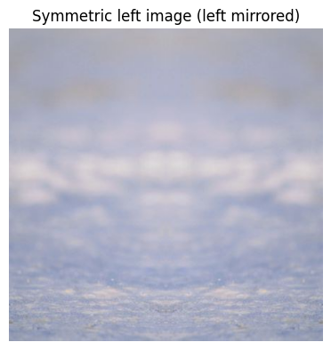

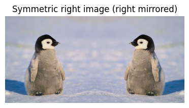

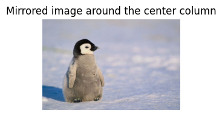

```python
plt.figure(figsize=(14, 6))

# mirror the left half to create a symmetric image
center = penguin.shape[0] // 2
left = penguin[:, :center]
left_flipped = np.fliplr(left)
symmetric = np.hstack([left, left_flipped])
plt.figure(figsize=(10, 5))
plt.subplot(1, 2, 1)
plt.imshow(symmetric)
plt.title("Symmetric left image (left mirrored)")
plt.axis('off')
plt.show()

# mirror the right half to create a symmetric image
center = penguin.shape[0] // 2
right = penguin[:, center:]
right_flipped = np.fliplr(right)
symmetric = np.hstack([right_flipped, right])
plt.figure(figsize=(10, 5))
plt.subplot(1, 2, 2)
plt.imshow(symmetric)
plt.title("Symmetric right image (right mirrored)")
plt.axis('off')
plt.show()


# mirror the image around the center column
center = penguin.shape[0] // 2
symmetric = np.hstack([right_flipped, left_flipped])
plt.figure(figsize=(10, 5))
plt.subplot(1, 3, 1)
plt.imshow(symmetric)
plt.title("Mirrored image around the center column")
plt.axis('off')
plt.show()
```

### Q10: Creative Task

Create a custom 300×300 image that contains:

1. A red square in the top-left corner (100×100)
2. A green circle in the center (radius = 50 pixels)
3. A blue diagonal line from (250, 50) to (50, 250)
4. Your initials in yellow somewhere in the image

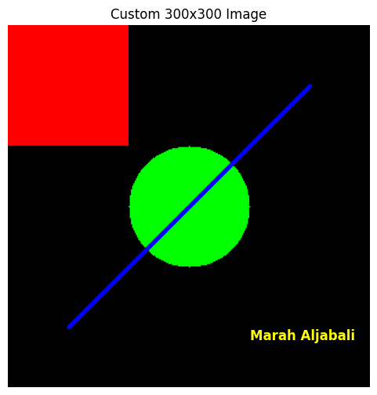

```python
# Create a 300x300 RGB image
img = np.zeros((300, 300, 3), dtype=np.uint8)  # black background

# Red square in top-left (100x100)
img[0:100, 0:100] = [255, 0, 0]

# Green circle in center (radius = 50)
c = 150
y, x = np.ogrid[:300, :300]
mask_circle = (x - c)**2 + (y - c)**2 <= 50**2
img[mask_circle] = [0, 255, 0]

# Blue diagonal line from (250,50) to (50,250)
x0, y0 = 250, 50
x1, y1 = 50, 250

# sample many points along the line and draw a small thickness
xs = np.linspace(x0, x1, 500)
ys = np.linspace(y0, y1, 500)
for xf, yf in zip(xs, ys):
  xi = int(round(xf))
  yi = int(round(yf))
  # draw a 3x3 square around the point for thickness
  r0 = max(0, yi - 1); r1 = min(300, yi + 2)
  c0 = max(0, xi - 1); c1 = min(300, xi + 2)
  img[r0:r1, c0:c1] = [0, 0, 255]



plt.figure(figsize=(6, 6))
plt.imshow(img)

# Initials in yellow - overlay using matplotlib text (quick and readable)
plt.text(200, 260, 'Marah Aljabali', color='yellow', fontsize=12, weight='bold')

plt.title("Custom 300x300 Image")
plt.axis('off')
plt.show()
```